# PREGVAL Book - 6 Quality Check: Processing MBDS. Empadronados

Author

Francisco Sanchez-Saez

Published

June 11, 2023

## 6.1 Input

The table to be analysed is **mbds.csv**.

## 6.2 Check variables

The variables extracted from mbds are: sip, fecha_ingreso, fecha_alta, dpto_cod, hosp_cod, serv_ing_cod, serv_ing_desc, tipo_activ, circ_ing_cod, circ_ing_desc, circ_alta_cod, circ_alta_desc, d1, d2, d3, d4, d5, d6, d7, d8, d9, d10, d11, d12, d13, d14, d15, d16, d17, d18, d19, d20, d21, d22, d23, d24, d25, d26, d27, d28, d29, d30, p1, p2, p3, p4, p5, p6, p7, p8, p9, p10, p11, p12, p13, p14, p15, p16, p17, p18, p19, p20, p21, p22, p23, p24, p25, p26, p27, p28, p29, p30, tipo_codigo, fecha_parto, parto_multiple, semana_gest, peso1, sexo1, peso2, sexo2, peso3, sexo3, ind_uci, and estancias_uci.

### 6.2.1 Check mandatory vars

All mandatory vars are present.

### 6.2.2 Check all vars

dpto_desc and hosp_desc were not extracted.

### 6.2.3 Completeness

In Figure 6.1 is shown the percentage of non-missing values for each variable. Non-mandatory variables are shown at the bottom of the figure.

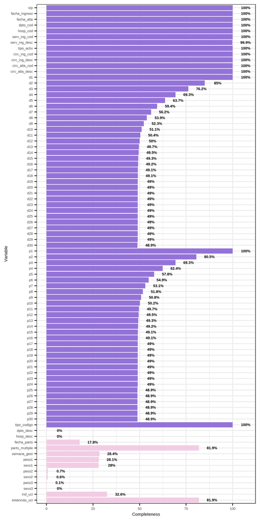

Figure 6.1: Variables completeness

## 6.3 Check content

The **mbds** table has a total of **n = 1 ‍181 ‍384 observations**.

### 6.3.1 Population

- In **mbds** table there are 605 ‍156 distinct individuals. All the individuals are included in the target population. Therefore, there are 605 ‍156 individuals included in the target population out of the 1 ‍842 ‍818 total individuals in the cohort. These represents 32.84% of the total.
- The Table 7.1 shows the number of individuals per year of the study period.

Table 6.1: Number of individuals per year of calculation

| Year of admission | Count of distinct individuals |
| --- | --- |
| 2009 | 685 |
| 2010 | 86193 |
| 2011 | 88683 |
| 2012 | 90579 |
| 2013 | 93761 |
| 2014 | 95620 |
| 2015 | 95234 |
| 2016 | 96204 |
| 2017 | 95911 |
| 2018 | 65042 |
| 2019 | 65251 |
| 2020 | 56963 |
| 2021 | 45062 |

### 6.3.2 Date of the admission

The variable *fecha_ingreso* is missing in **0 observations**, so it is 100% complete. The minimum and maximum date are *2009-01-21* and *2021-12-30* respectively. Table 7.2 shows the number of admissions per year of *fecha_ingreso*.

All dates are inside the study period.

Table 6.2: Number of admissions each year of calculation

| Year of the admission | Count |
| --- | --- |
| 2009 | 685 |
| 2010 | 105903 |
| 2011 | 106688 |
| 2012 | 109094 |
| 2013 | 113880 |
| 2014 | 116282 |
| 2015 | 115387 |
| 2016 | 116509 |
| 2017 | 116719 |
| 2018 | 79315 |
| 2019 | 79473 |
| 2020 | 67952 |
| 2021 | 53497 |

The month and year with less admissions was January 2009 with n = 1, May 2009 with n = 1, June 2009 with n = 1, September 2009 with n = 1 and the month and year with more admissions was October 2014 with n = 11139.

In Figure 6.2, Figure 6.3, and Figure 6.4 are presented the frequencies of years, months, and days of the admissions respectively.

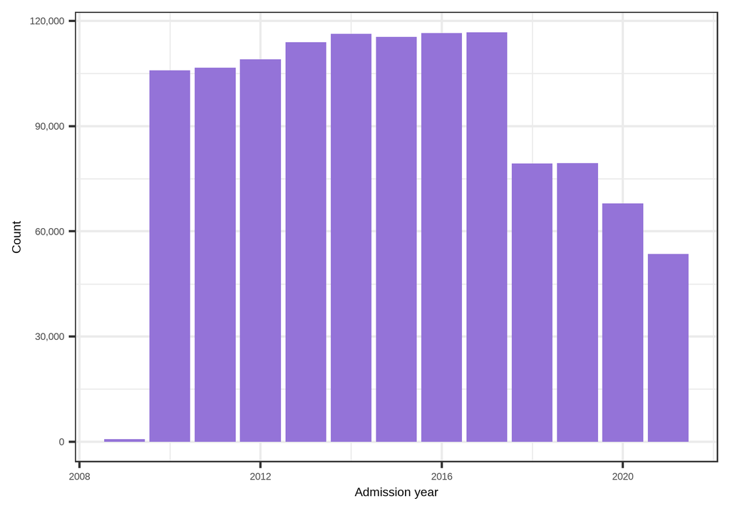

Figure 6.2: Admission year

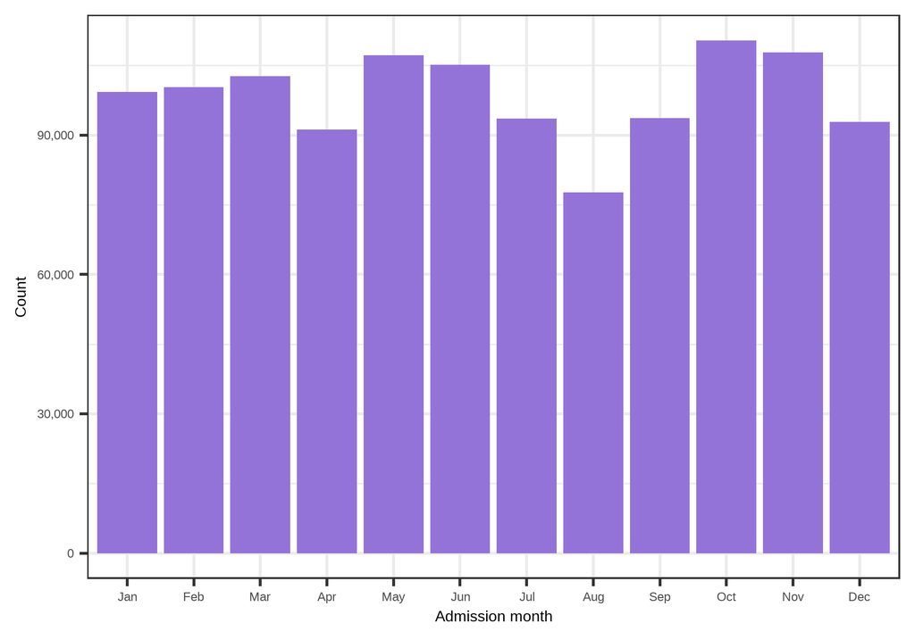

Figure 6.3: Admission month

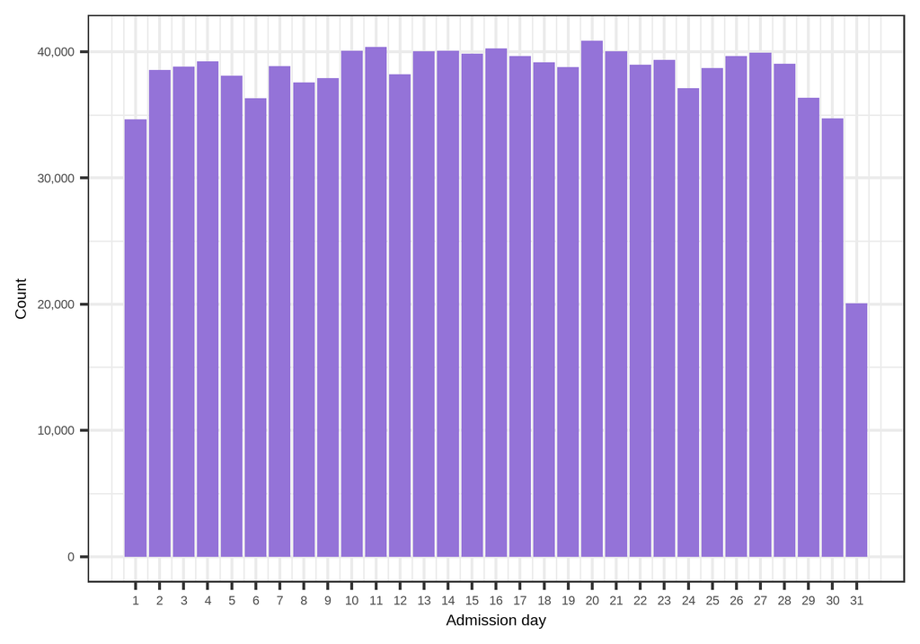

Figure 6.4: Admission day

### 6.3.3 Date of the discharge

The variable *fecha_alta* is missing in **0 observations**, so it is 100% complete. The minimum and maximum date are *2010-01-01* and *2021-12-31* respectively. Table 7.3 shows the number of discharges per year of *fecha_alta*.

All dates are inside the study period.

Table 6.3: Number of discharges each year of calculation

| Year of the discharge | Count |
| --- | --- |
| 2010 | 105849 |
| 2011 | 106763 |
| 2012 | 109114 |
| 2013 | 113815 |
| 2014 | 116277 |
| 2015 | 115344 |
| 2016 | 116518 |
| 2017 | 116139 |
| 2018 | 80095 |
| 2019 | 79410 |
| 2020 | 68124 |
| 2021 | 53936 |

The month and year with less discharges was January 2021 with n = 2973 and the month and year with more discharges was October 2014 with n = 11268.

In Figure 6.5, Figure 6.6, and Figure 6.7 are presented the frequencies of years, months, and days of the visits respectively.

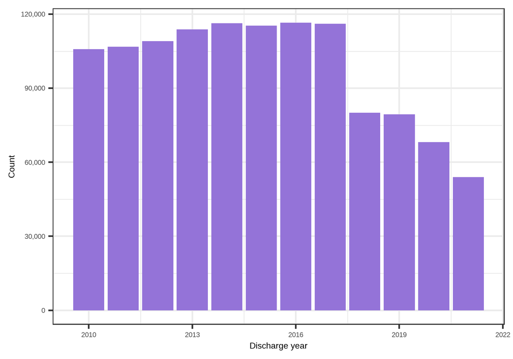

Figure 6.5: Discharge year

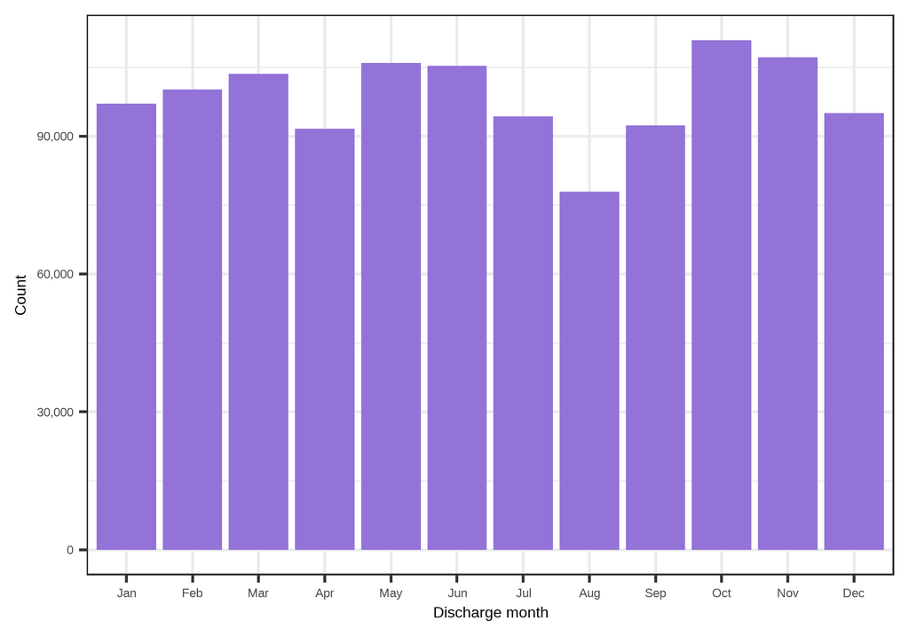

Figure 6.6: Discharge month

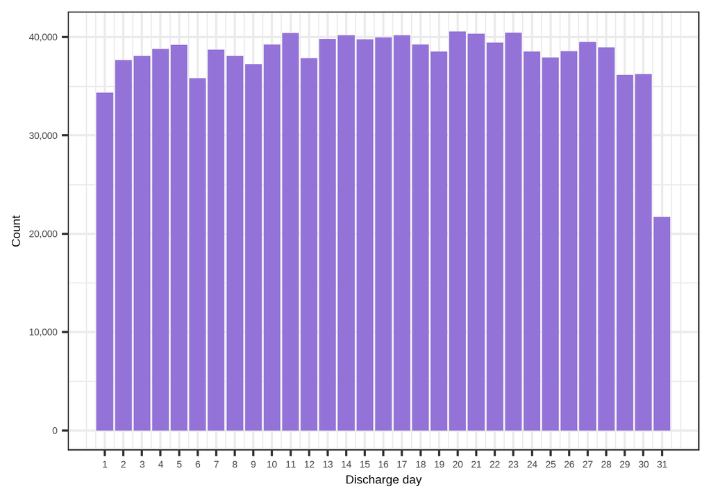

Figure 6.7: Discharge day

### 6.3.4 Visit service

The variable *serv_ing_desc* is missing in **594 observations**, so it is 99.9% complete. Table 7.4 shows all the services used in the primary care visits arranged by alphabetic order. Figure 6.8 shows the count of the utilization of each visit service. Finally, Figure 6.9 shows the count of visits for the 10 most used services per year.

Table 6.4: Healths services used in the primary care visits

| Service | Count | Percentage | valid_percent |
| --- | --- | --- | --- |
| ALERGIA | 138 | 0.01% | 0.01% |
| ALERGIA INFANTIL | 76 | 0.01% | 0.01% |
| ANESTESIA / REANIMACION | 2240 | 0.19% | 0.19% |
| CARDIOLOGIA | 7810 | 0.66% | 0.66% |
| CARDIOLOGIA INFANTIL | 394 | 0.03% | 0.03% |
| CARDIOVASCULAR INFANTIL | 69 | 0.01% | 0.01% |
| CIRUGIA CARDIACA | 668 | 0.06% | 0.06% |
| CIRUGIA CARDIOVASCULAR | 934 | 0.08% | 0.08% |
| CIRUGIA GENERAL | 83237 | 7.05% | 7.05% |
| CIRUGIA GENERAL Y DIGESTIVO | 33393 | 2.83% | 2.83% |
| CIRUGIA MAXILOFACIAL | 42464 | 3.59% | 3.60% |
| CIRUGIA MAXILOFACIAL INFANTIL | 484 | 0.04% | 0.04% |
| CIRUGIA ORTOPEDICA Y TRAUMATOLOGÍA | 79644 | 6.74% | 6.74% |
| CIRUGIA PEDIATRICA | 4032 | 0.34% | 0.34% |
| CIRUGIA PLASTICA | 18614 | 1.58% | 1.58% |
| CIRUGIA PLASTICA INFANTIL | 871 | 0.07% | 0.07% |
| CIRUGIA TORACICA | 3570 | 0.30% | 0.30% |
| CIRUGIA VASCULAR | 8735 | 0.74% | 0.74% |
| CUIDADOS PALIATIVOS | 414 | 0.04% | 0.04% |
| CURIE -TERAPIA | 764 | 0.06% | 0.06% |
| DERMATOLOGIA | 13156 | 1.11% | 1.11% |
| ENDOCRINOLOGIA | 2318 | 0.20% | 0.20% |
| ENDOCRINOLOGIA INFANTIL | 162 | 0.01% | 0.01% |
| ENDOSCOPIA | 6 | 0.00% | 0.00% |
| ESCOLARES | 2521 | 0.21% | 0.21% |
| FECUNDACION IN VITRO | 31 | 0.00% | 0.00% |
| GINECOLOGIA | 160981 | 13.63% | 13.63% |
| HEMATOLOGIA | 5730 | 0.49% | 0.49% |
| HEMATOLOGIA INFANTIL | 103 | 0.01% | 0.01% |
| HEMODINAMICA | 291 | 0.02% | 0.02% |

[output cut: 71 more lines]

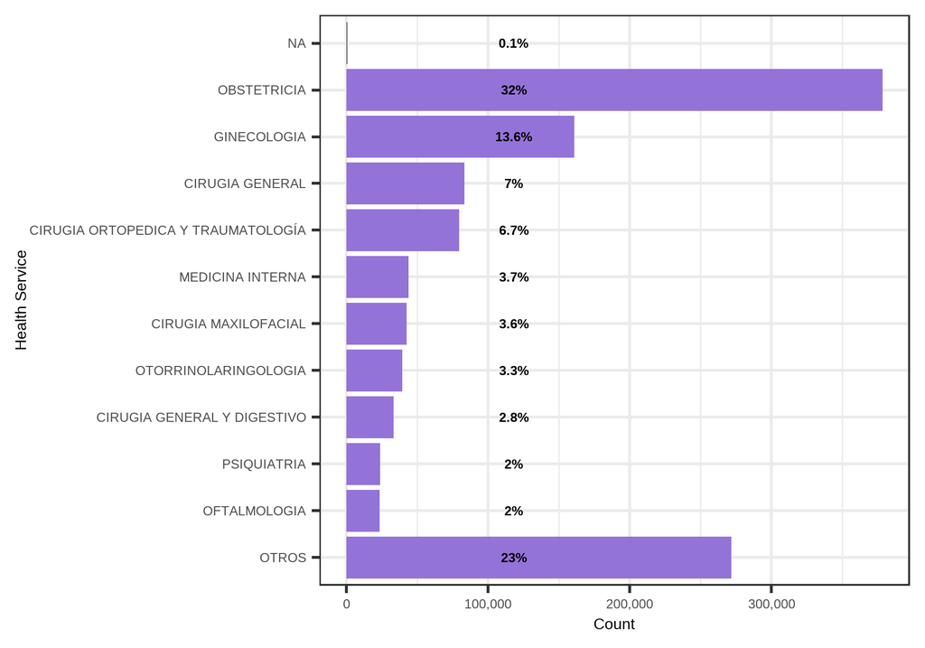

Figure 6.8: Primary care visit services

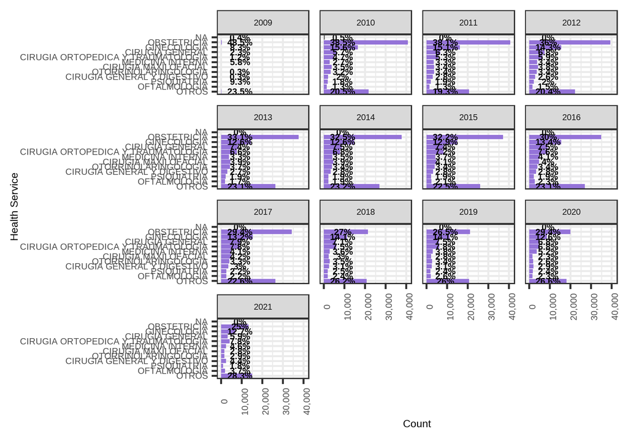

Figure 6.9: Most used primary care visit services per year

### 6.3.5 Diagnoses codes

The variable *d1* is missing in **0 observations**, so it is 100% complete. Figure 6.10 shows the most employed diagnoses codes. Finally, Figure 6.11 shows the count of the 10 most employed codes per year.

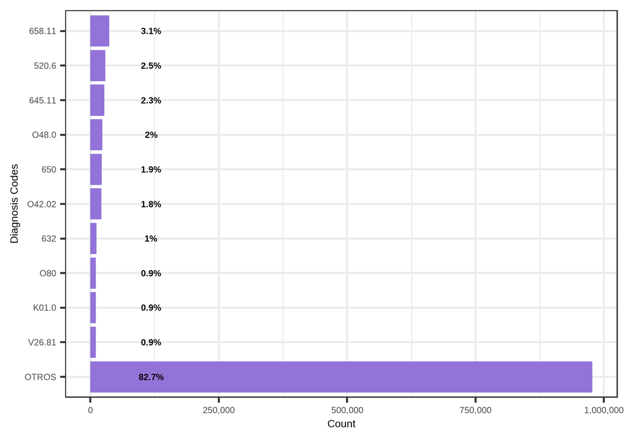

Figure 6.10: Diagnosis codes used in primary care visits

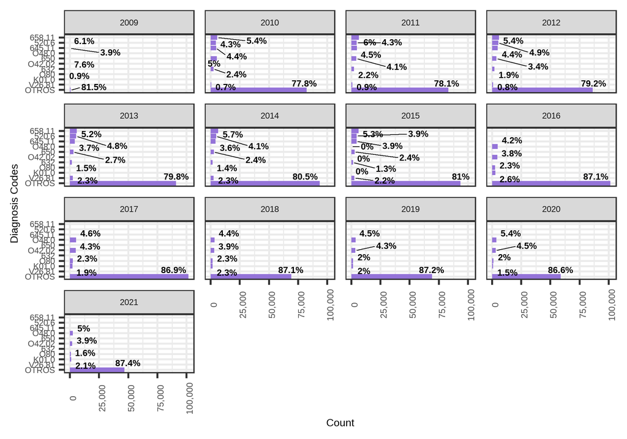

Figure 6.11: Diagnosis codes used in primary care visits per year

### 6.3.6 Code vocabulary

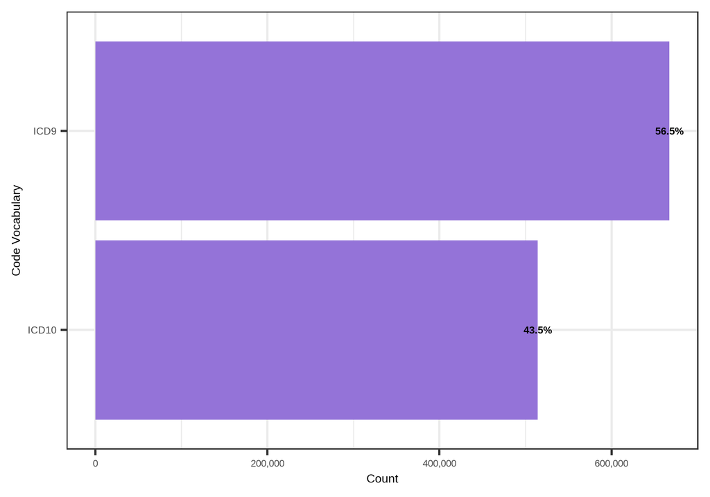

Figure 6.12: Code vocabularies used in primary care visits

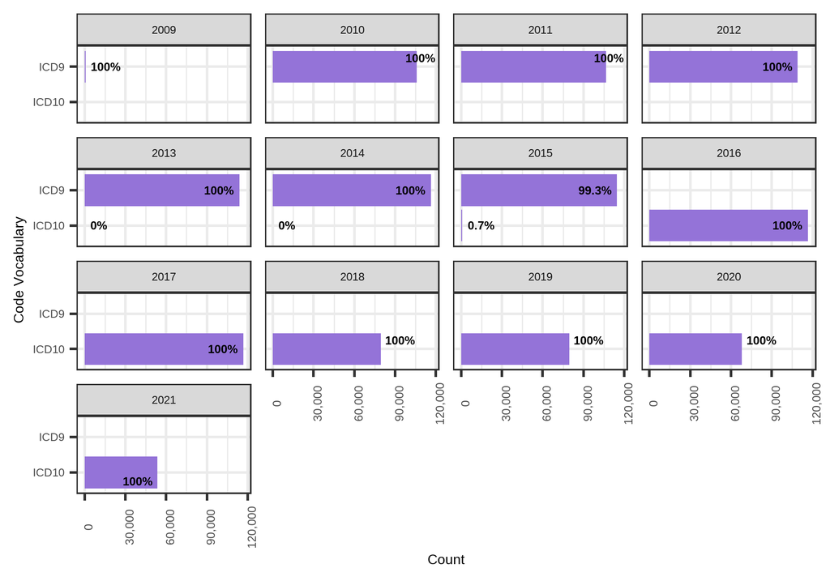

Figure 6.13: Code vocabularies used in primary care visits per year

### 6.3.7 Date of the labour

The variable *fecha_parto* is missing in **971601 observations**, so it is 17.8% complete. The minimum and maximum date are *2009-12-22* and *2021-12-29* respectively. Table 6.5 shows the number of discharges per year of *fecha_parto*.

All dates are inside the study period.

Table 6.5: Number of discharges each year of calculation

| Year of the labour | Count |
| --- | --- |
| 2009 | 214 |
| 2010 | 29106 |
| 2011 | 28237 |
| 2012 | 29421 |
| 2013 | 26992 |
| 2014 | 26456 |
| 2015 | 25552 |
| 2016 | 11613 |
| 2017 | 10635 |
| 2018 | 6245 |
| 2019 | 5903 |
| 2020 | 5513 |
| 2021 | 3896 |
| NA | 971601 |

In Figure 6.14, Figure 6.15, and Figure 6.16 are presented the frequencies of years, months, and days of the visits respectively.

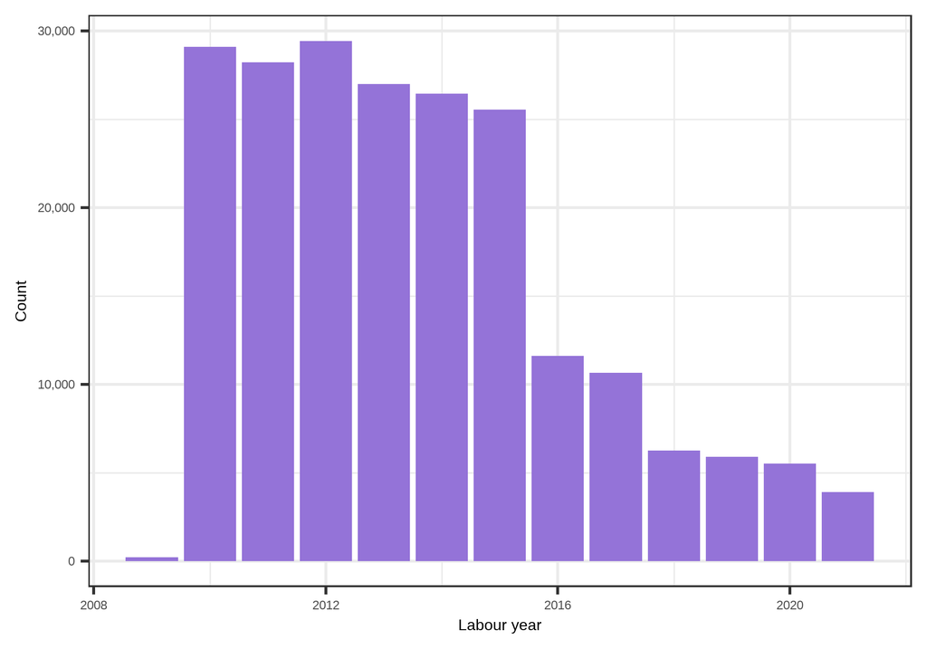

Figure 6.14: Labour year

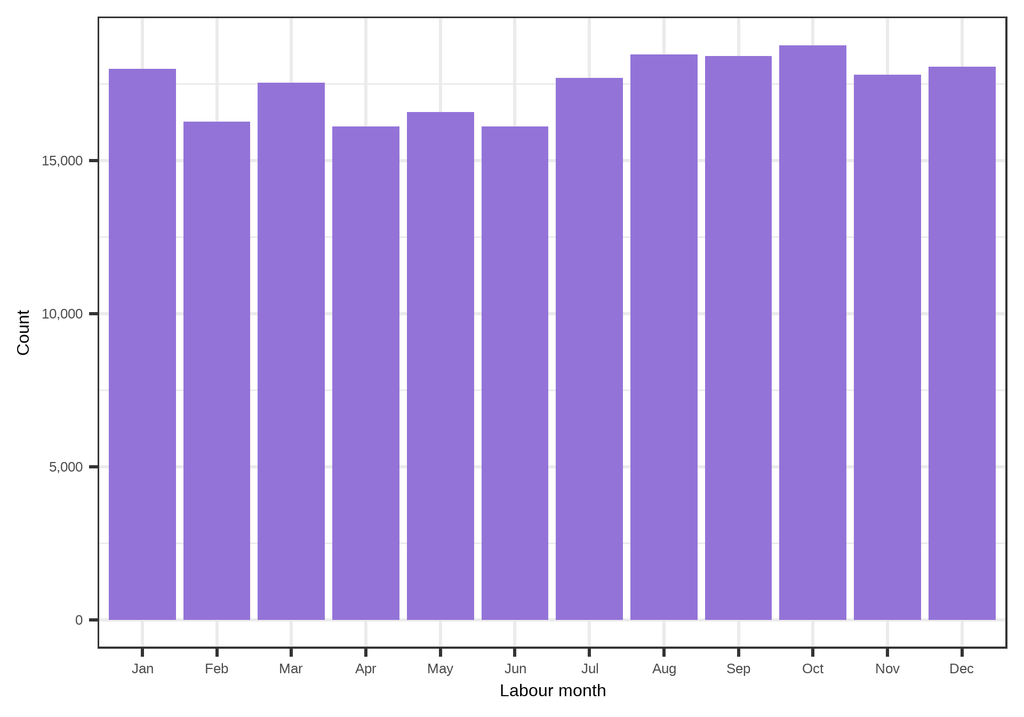

Figure 6.15: Labour month

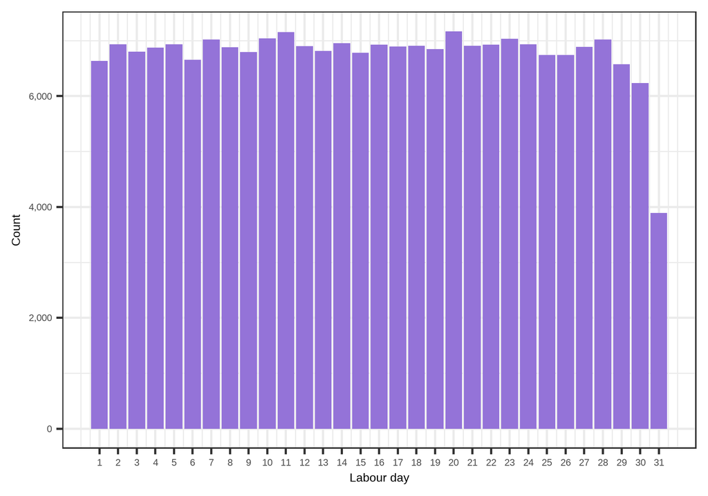

Figure 6.16: Labour day